# Group project - G2

Bayesian Multilevel Models

Hamza Sajjad

Kafia Elmi

Ebenezer Tafese

Natalia Latinović

Bas Verkennis

2023-05-31

# Checklist

The submission includes the following.

- RMD/R document where it’s clear what is the code that corresponds to each question.
- Dataset
- html/PDF document with the following
  - Numbered questions and answers with text and all the necessary code.
  - Cover with group number and name of all group members
  - Details of specification of the work done by group members (e.g., who found the data, who did the pre-processing, who answered which questions, etc).

# Group project

For the project, we use the following packages:

```r
library(dplyr)
library(brms)
library(ggplot2)
library(tidyr)
library(glue)
library(loo)
library(caret)
library(reshape2)
ggplot2::theme_set(ggplot2::theme_light()) # nicer theme
options(mc.cores = parallel::detectCores()) # paralellize if possible
options(brms.file_refit = "on_change") # save the files if the model has changed
library(ggrepel) #to avoid overlapping texts



#install:
# install.packages("remotes")
# remotes::install_github("n-kall/priorsense")
library(priorsense)
#nice plotting theme:
theme_set(theme_linedraw() +
            theme(panel.grid = element_blank()))
```

## 1. Dataset Selection (1pt)

Select a dataset with clusters such as schools, regions, or people with multiple observations per individual. (From for example, https://www.kaggle.com/) It would be a good idea to choose a smallish dataset (not too many rows, e.g., less than 1000) or subset it so that fitting the models doesn’t take too long.

1. Describe the dataset with a couple of short sentences. What was its intended use? Are there papers that reference it? Provide information on how to obtain the dataset, including its source and any necessary preprocessing steps/feature engineering.

The dataset contains user experiences in virtual reality (VR), including physiological responses, emotional states, and user preferences. It aims to improve VR technology by analyzing how users respond to different VR environments. Variables include user ID, age, gender, VR headset type, duration, motion sickness rating, and immersion level. This dataset enables developers to optimize VR systems and create tailored, immersive experiences for enhanced user satisfaction.

You can obtain the dataset by downloading it from the kaggle repository, following this link: https://www.kaggle.com/datasets/aakashjoshi123/virtual-reality-experiences

```r
# load the data and preprocessing steps go here
f <- file.choose()
data <- read.csv(file = f,stringsAsFactors = F)
data$Age <- as.numeric(x = scale(x = data$Age,center = T))
data$Duration <- as.vector(x = scale(x = data$Duration,center = T))
data$ImmersionLevel <- ifelse(data$ImmersionLevel >= 3,yes = 1,no = 0)
data$MotionSickness <- as.numeric(x = scale(x = data$MotionSickness,center = T,
                                            scale = F))
data$Gender <- factor(data$Gender, levels = c("Female", "Male", "Other"),
                      labels = c(0, 1, 2))
data$Gender <- as.numeric(data$Gender)
data$VRHeadset <- factor(data$VRHeadset,
                         levels = c("HTC Vive", "PlayStation VR", "Oculus Rift")
                         ,labels = c(0, 1, 2))
data$VRHeadset <- as.numeric(data$VRHeadset)
print(data)
```

```
   UserID         Age Gender VRHeadset   Duration MotionSickness ImmersionLevel
1       1  0.06821459      2         1 -1.2038415          2.474              1
2       2  0.31717294      1         1 -0.8008955         -3.526              0
3       3 -1.01060493      2         2 -1.0170389         -1.526              0
4       4 -0.51268823      2         1  0.6341668          0.474              1
5       5  0.98106187      2         2 -0.6421968         -1.526              0
6       6  0.56613129      3         3 -0.2722348          1.474              1
7       7  0.81508963      3         3  1.2510033          1.474              1
8       8  0.23418682      3         3 -0.6100509          2.474              0
9       9  1.39599245      1         2 -0.9970371         -0.526              0
10     10  1.72793691      2         3  0.1201387         -0.526              1
11     11 -0.18074376      2         3  0.6845956         -3.526              0
12     12 -1.34254939      3         2 -0.4736470          2.474              1
13     13  0.48314517      2         2  1.6212754         -0.526              1
14     14 -0.92761881      1         2 -0.4181444         -0.526              1
15     15 -1.34254939      2         1  1.5585945          1.474              1
16     16 -0.42970211      1         3  0.7688005         -4.526              1
17     17  0.73210352      2         2 -0.6160620          4.474              1
 [ reached 'max' / getOption("max.print") -- omitted 983 rows ]
```

2. Report its number of observations, columns (with their meaning) and their data types.

## 2. Research Question (0.5pt)

Formulate a research question that involves predicting a specific outcome variable based on the available dataset.

How do different factors, including VR headset type, duration of VR experience, motion sickness rating, and user demographics (age and gender), affect the feeling of having felt immersed reported by users in virtual reality environments?

## 3. Model Exploration (3pt)

1. Fit multiple appropriate models to the data set (as many models as there are members in the group, with a minimum of two models). Models might vary in the multilevel structure, informativeness of their priors (but not just trivial changes), model of the data/likelihood, etc. (I recommend not to use no pooling models since they tend to take a long time and it’s very hard to assign good priors).

Since our group consists of five members. We have made five models.

Model 1: A pooled model

Model 2: An varying intercepts model

Model 3: A varying slopes model

Model 4: A varying intercepts & slopes model

Model 5: A correlated varying intercepts & slopes model

```r
# Model 1 - Pooled model
def_priors_f <-
  c(prior(normal(0,1), class = Intercept),
    prior(normal(0, 1), class = 'b', coef = Age),
    prior(normal(0, 1), class = 'b', coef = Duration))

model1 <- brm(ImmersionLevel ~ Age + Duration ,  data = data,
              family = bernoulli(link = logit),prior = def_priors_f,
              file = "model1",save_model = 'model1')
```

```r
# Model 2 - Varying intercept model:
# Priors Normal - uninformative
def_priors_model_2 <- c(
  prior_string(glue('exponential({1/sd(data$ImmersionLevel)}'),
               class = 'sd'))
model2 <- brm(formula = ImmersionLevel ~ MotionSickness + Duration + (1 | VRHeadset)
              ,data = data, control = list(adapt_delta = 0.999),family = bernoulli
              ,cores = 12, iter = 6e3,seed = 123, file = 'model2',save_model = 'model2')
```

```r
# Model 3 - Varying slopes model
def_priors_model_2 <- c(
  prior_string(glue('exponential({1/sd(data$ImmersionLevel)}'),
               class = 'sd'))

model3 <- brm(ImmersionLevel ~ Duration + MotionSickness + Age + Gender
              + (-1 + Duration + MotionSickness + Age + Gender | VRHeadset),
              data = data, family = bernoulli(link = logit),
              prior = def_priors_model_2, iter = 8e3,
              control = list(adapt_delta = 0.95),seed = 123,
              file = 'model3',save_model = 'model3')
```

```r
#Model 4 - Varying intercept and slopes model:

# Define/set priors
prior_def <- set_prior("normal(0, 1)", class = "b") +
  set_prior("cauchy(0, 1)", class = "sd")

# Fitting the model
model4 <- brm(ImmersionLevel ~ Age + Gender + Duration + MotionSickness +
                     (1 + Age + Gender + Duration + MotionSickness || VRHeadset),
                   data = data,
                   prior = prior_def,
                   family = bernoulli(link = logit), iter = 6e3,
                   control = list(adapt_delta = 0.99),seed = 123,
              file = 'model4',save_model = 'model4')
```

```r
# Model 5 - Correlated varying intercept and slopes model
def_priors <- c(
  prior_string(glue("normal({mean(data$ImmersionLevel)},
                    {2.5* sd(data$ImmersionLevel)})"), class = "Intercept"),
  prior_string(glue("normal(0, {5 * sd(data$ImmersionLevel)})"), class = "b"),
  prior_string(glue("exponential({ 1/sd(data$ImmersionLevel)})"), class = "sd")
)

def_priors_hc <- c(
  def_priors,
  prior(lkj(2), class = "cor")
)

model5 <- brm(ImmersionLevel ~ MotionSickness * Gender
              + (1 + MotionSickness | VRHeadset), # 1 + is optional
              data = data,
              prior = def_priors_hc,
              iter = 10000,
              family = bernoulli(link = "logit"),
              control = list(adapt_delta = .999),
              seed = 123,
              sample_prior = TRUE
              , file = 'model5',save_model = 'model5')
```

2. Explain each model and describe its structure (what they assume about potential population- level or group-level effects), and the type of priors used.

**Pooled model -** This models fits a Bayesian logistic regression model to predict ImmersionLevel based on the Age and Duration variables. For the intercept, Age and Duration, the prior specifies a normal distribution with a mean of 0 and a standard deviation of 1 which allows for a wide range of possible values. The reason for setting these priors is due to the fact that the majority of the values centered around zero with somewhat following a normal distribution.

**Varying intercept & slopes model** - A varying intercept and varying slopes model is a multilevel or hierarchical model. It is used to account for the potential variation in the relationship between independent and dependent variables across different groups. In a varying intercept and varying slopes model, both the intercept and slopes of the regression equation are allowed to vary across the groups. The idea is that different groups may have a different baseline level (intercept) and a different relationship (slope) to the dependent variable. Because of the varying effects, the model can provide more accurate estimates and predictions, as it takes the heterogeneity across groups into account. It allows for the identification of group-specific patterns and can provide insights into how the relationships between variables differ across the different levels of the grouping factor.

**Correlated varying intercept & varying slopes model** -

Assumptions: Population-level effects: The model assumes that there are fixed effects representing the average relationships between the predictors (MotionSickness, and Gender) and the outcome variable (ImmersionLevel) across the entire population. These effects are assumed to be constant and the same for all levels of the grouping variable (VRHeadset).

Group-level effects: The model incorporates random effects to capture potential variations in the relationships between the predictors and the outcome across different levels of the grouping variable (VRHeadset). Specifically, the model allows for random intercepts and slopes for the predictor MotionSickness within each level of VRHeadset. This means that the effects of MotionSickness on ImmersionLevel can vary across different VRHeadset groups.

## 4. Model checking (2.5pt)

1. Perform a prior sensitivity analysis for each model and modify or discard the model if appropriate. Justify.

**Model 1 - Pooled Model**

```r
print(def_priors_f)
```

```
        prior     class     coef group resp dpar nlpar   lb   ub source
 normal(0, 1) Intercept                                <NA> <NA>   user
 normal(0, 1)         b      Age                       <NA> <NA>   user
 normal(0, 1)         b Duration                       <NA> <NA>   user
```

```r
pss_model1 <- powerscale_sensitivity(x = model1)
pss_model1
```

```
Sensitivity based on cjs_dist:
# A tibble: 3 × 4
  variable       prior likelihood diagnosis
  <chr>          <dbl>      <dbl> <chr>
1 b_Intercept 0.00356      0.0901 -
2 b_Age       0.000784     0.0868 -
3 b_Duration  0.00149      0.0942 -
```

**Model 2 - Varying intercepts model**

```r
# Default priors
pss_model2 <- powerscale_sensitivity(x = model2)

# Prior-data conflict detected!
pss_model2
```

```
Sensitivity based on cjs_dist:
# A tibble: 7 × 4
  variable                    prior likelihood diagnosis
  <chr>                       <dbl>      <dbl> <chr>
1 b_Intercept              0.0211       0.0172 -
2 b_MotionSickness         0.000601     0.0811 -
3 b_Duration               0.000337     0.0795 -
4 sd_VRHeadset__Intercept  0.111        0.0881 prior-data conflict
5 r_VRHeadset[1,Intercept] 0.0205       0.0150 -
6 r_VRHeadset[2,Intercept] 0.0207       0.0144 -
7 r_VRHeadset[3,Intercept] 0.0206       0.0166 -
```

```r
# Setting up a new prior using a very wide exponential dist.
new_prior <- set_prior(prior = "exponential(0.1)",class = 'sd',
                       coef = 'Intercept', group = 'VRHeadset')

# Fitting new model with wider prior
model2a <- brm(formula = ImmersionLevel ~ MotionSickness +
                 Duration + (1 | VRHeadset),
               data = data, control = list(adapt_delta = 0.999),
               family = bernoulli, cores = 12, iter = 6e3,seed = 123,
               prior = new_prior,file = 'm2a',save_model = 'm2a')

# Visual diagnostics only loaded once, so are left out.
# Maybe it was too hard to load so we just use the diagnostics table
pss_model2a <- powerscale_sensitivity(x = model2a)
pss_model2a
```

```
Sensitivity based on cjs_dist:
# A tibble: 7 × 4
  variable                    prior likelihood diagnosis
  <chr>                       <dbl>      <dbl> <chr>
1 b_Intercept              0.0104       0.0213 -
2 b_MotionSickness         0.000400     0.0829 -
3 b_Duration               0.00106      0.0821 -
4 sd_VRHeadset__Intercept  0.0640       0.100  prior-data conflict
5 r_VRHeadset[1,Intercept] 0.00970      0.0192 -
6 r_VRHeadset[2,Intercept] 0.0101       0.0181 -
7 r_VRHeadset[3,Intercept] 0.0109       0.0187 -
```

```r
# Comparison (as expected no difference)
loo(model2a,model2,compare = T)
```

```
Output of model 'model2a':

Computed from 12000 by 1000 log-likelihood matrix

         Estimate   SE
elpd_loo   -677.9  6.2
p_loo         4.1  0.1
looic      1355.7 12.4
------
Monte Carlo SE of elpd_loo is 0.0.

All Pareto k estimates are good (k < 0.5).
See help('pareto-k-diagnostic') for details.

Output of model 'model2':

Computed from 12000 by 1000 log-likelihood matrix

         Estimate   SE
elpd_loo   -677.9  6.2
p_loo         4.1  0.1
looic      1355.8 12.4
------
Monte Carlo SE of elpd_loo is 0.0.

All Pareto k estimates are good (k < 0.5).
See help('pareto-k-diagnostic') for details.

Model comparisons:
        elpd_diff se_diff
model2a 0.0       0.0
model2  0.0       0.0
```

```r
# For some reason, whatever prior i use, the data-conflict doesntseem to resolve
# Lets just go forward with the original model.
```

For model 2 we unexpectedly find there is a prior_data conflict for the standard deviation of the group-level intercepts. An attempt to fix this may be to try to specify a wider prior for this parameter, as shown in the code above. However, as shown in the comments a wider prior did not seem to alleviate the issue.

```r
alternative_priors <-   c(prior(normal(0, 5), class = "b"),
  # Alternative priors for fixed effects coefficients
  prior(normal(0, 5), class = "Intercept"),
  # Alternative prior for the intercept
  prior(cauchy(0, 2.5), class = "sd")
  # Alternative prior for the residual standard deviation
)

model3a <- brm(ImmersionLevel ~ Duration + MotionSickness + Age + Gender +
               (-1 + Duration + MotionSickness + Age + Gender | VRHeadset),
               data = data, family = bernoulli(link = logit),
               prior = alternative_priors, iter = 8e3,
               control = list(adapt_delta = 0.95),seed = 123, file = 'm3a',
               save_model = 'm3a')
# Comparison results in alternative model not being better and even slightly worse
loo(model3,model3a,compare = T)
```

```
Output of model 'model3':

Computed from 16000 by 1000 log-likelihood matrix

         Estimate   SE
elpd_loo   -680.0  6.6
p_loo        10.1  0.2
looic      1360.0 13.1
------
Monte Carlo SE of elpd_loo is 0.0.

All Pareto k estimates are good (k < 0.5).
See help('pareto-k-diagnostic') for details.

Output of model 'model3a':

Computed from 16000 by 1000 log-likelihood matrix

         Estimate   SE
elpd_loo   -680.4  6.7
p_loo        10.9  0.2
looic      1360.9 13.3
------
Monte Carlo SE of elpd_loo is 0.0.

All Pareto k estimates are good (k < 0.5).
See help('pareto-k-diagnostic') for details.

Model comparisons:
        elpd_diff se_diff
model3   0.0       0.0
model3a -0.4       0.3
```

**Model 4 - Varying intercepts and slopes model**

```r
print(prior_def,data = data)
```

```
        prior class coef group resp dpar nlpar   lb   ub source
 normal(0, 1)     b                            <NA> <NA>   user
 cauchy(0, 1)    sd                            <NA> <NA>   user
```

```r
pss_model4 <- powerscale_sensitivity(x = model4)
pss_model4
```

```
Sensitivity based on cjs_dist:
# A tibble: 25 × 4
   variable                      prior likelihood diagnosis
   <chr>                         <dbl>      <dbl> <chr>
 1 b_Intercept                  0.0289    0.0374  -
 2 b_Age                        0.0186    0.0251  -
 3 b_Gender                     0.0210    0.0306  -
 4 b_Duration                   0.0337    0.0129  -
 5 b_MotionSickness             0.0208    0.00712 -
 6 sd_VRHeadset__Intercept      0.205     0.0984  prior-data conflict
 7 sd_VRHeadset__Age            0.113     0.0931  prior-data conflict
 8 sd_VRHeadset__Gender         0.141     0.0576  prior-data conflict
 9 sd_VRHeadset__Duration       0.166     0.0324  weak likelihood
10 sd_VRHeadset__MotionSickness 0.113     0.0320  weak likelihood
# ℹ 15 more rows
```

```r
# Here i just defined some alternative priors
prior_spec_1 <- set_prior("normal(0, 1)", class = "b") +
  set_prior("cauchy(0, 1)", class = "sd")

prior_spec_2 <- set_prior("normal(0, 10)", class = "b") +
  set_prior("cauchy(0, 10)", class = "sd")

# I tried fitting the best performing model to the alternative priors
model_prior_1 <- brm(ImmersionLevel ~ Age + Gender + Duration + MotionSickness +
                    (1 + Age + Gender + Duration + MotionSickness || VRHeadset),
                     data = data,
                     prior = prior_spec_1,
                     family = bernoulli(link = logit),
                     control = list(adapt_delta = 0.9), file = 'mp1',
                    save_model = 'mp1')

model_prior_2 <- brm(ImmersionLevel ~ Age + Gender + Duration + MotionSickness +
                    (1 + Age + Gender + Duration + MotionSickness || VRHeadset),
                     data = data,
                     prior = prior_spec_2,
                     family = bernoulli(link = logit),
                     control = list(adapt_delta = 0.9), file = 'mp2',
                    save_model = 'mp2')

# I compared the initially best performing model (model 4) to the models
# with the new alternative priors I created
loo(model4,model_prior_1,model_prior_2,compare = T)
```

```
Output of model 'model4':

Computed from 12000 by 1000 log-likelihood matrix

         Estimate   SE
elpd_loo   -681.1  6.6
p_loo        11.6  0.2
looic      1362.3 13.3
------
Monte Carlo SE of elpd_loo is 0.0.

All Pareto k estimates are good (k < 0.5).
See help('pareto-k-diagnostic') for details.

Output of model 'model_prior_1':

Computed from 4000 by 1000 log-likelihood matrix

         Estimate   SE
elpd_loo   -681.0  6.6
p_loo        11.4  0.2
looic      1362.0 13.3
------
Monte Carlo SE of elpd_loo is 0.1.

All Pareto k estimates are good (k < 0.5).
See help('pareto-k-diagnostic') for details.

Output of model 'model_prior_2':

Computed from 4000 by 1000 log-likelihood matrix

         Estimate   SE
elpd_loo   -681.3  6.7
p_loo        11.8  0.2
looic      1362.6 13.4
------
Monte Carlo SE of elpd_loo is 0.1.

All Pareto k estimates are good (k < 0.5).
See help('pareto-k-diagnostic') for details.

Model comparisons:
              elpd_diff se_diff
model_prior_1  0.0       0.0
model4        -0.2       0.0
model_prior_2 -0.3       0.1
```

Alternative and wider priors were used to check whether these would improve the models accuracy. However the loo function did not show a significant change in model fit with the usage of the alternative priors over what was used in the initial attempt.

**Model 5 - Correlated varying intercepts and slopes model**

```r
print(def_priors_hc,data = data)
```

```
                           prior     class coef group resp dpar nlpar   lb   ub source
 normal(0.59,\n1.23019851584547) Intercept                            <NA> <NA>   user
     normal(0, 2.46039703169093)         b                            <NA> <NA>   user
    exponential(2.0321923395281)        sd                            <NA> <NA>   user
                          lkj(2)       cor                            <NA> <NA>   user
```

```r
pss_model5 <- powerscale_sensitivity(x = model5)
pss_model5
```

```
Sensitivity based on cjs_dist:
# A tibble: 17 × 4
   variable                                   prior likelihood diagnosis
   <chr>                                      <dbl>      <dbl> <chr>
 1 b_Intercept                              0.0137     0.0503  -
 2 b_MotionSickness                         0.0361     0.0138  -
 3 b_Gender                                 0.00244    0.0889  -
 4 b_MotionSickness:Gender                  0.00147    0.0807  -
 5 sd_VRHeadset__Intercept                  0.184      0.0815  prior-data confl…
 6 sd_VRHeadset__MotionSickness             0.203      0.0468  weak likelihood
 7 cor_VRHeadset__Intercept__MotionSickness 0.0540     0.0206  weak likelihood
 8 r_VRHeadset[1,Intercept]                 0.0227     0.0227  -
 9 r_VRHeadset[2,Intercept]                 0.0207     0.0211  -
10 r_VRHeadset[3,Intercept]                 0.0225     0.0193  -
11 r_VRHeadset[1,MotionSickness]            0.0374     0.0185  -
12 r_VRHeadset[2,MotionSickness]            0.0385     0.0141  -
13 r_VRHeadset[3,MotionSickness]            0.0393     0.0203  -
14 prior_Intercept                          0.00138    0.00554 -
15 prior_b                                  0.00102    0.00312 -
16 prior_sd_VRHeadset                       0.00300    0.0202  -
17 prior_cor_VRHeadset                      0.00115    0.00329 -
```

Model is modified. Adding the other variables: Age and Duration to the model didn’t succeed in any change in the predictions. They were both basically 0. However, while trying to tune the priors, I didn’t succeed in better priors that removed the prior-data conflict and the weak likelihoods while trying to predict Group-level effects and correlation. I conclude that this is caused by lack of data samples that can represent well the group level effects and correlation.

2. Conduct posterior predictive checks for each model to assess how well they fit the data. Explain what you conclude.

**Model 1 - Pooled model**

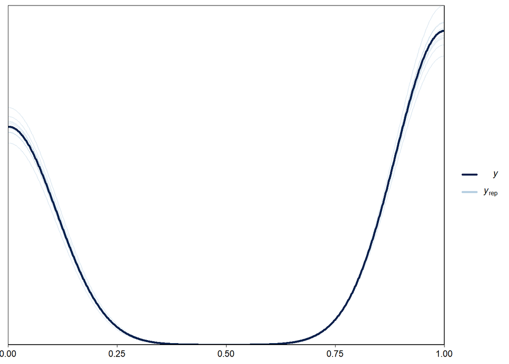

```r
pp_check(model1)
```

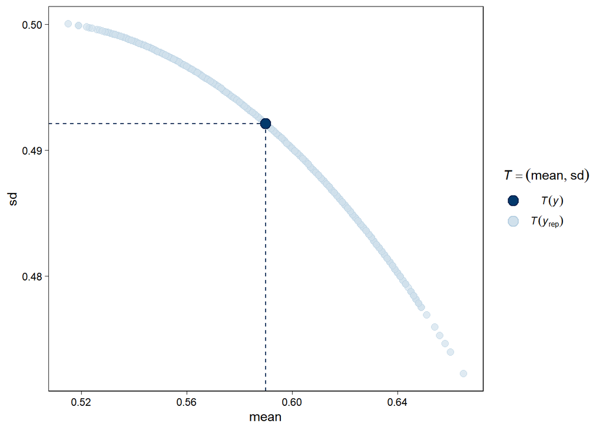

```r
pp_check(model1, type = "stat_2d")
```

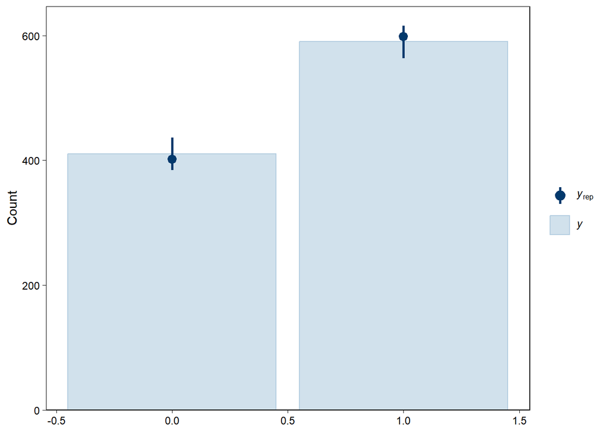

```r
pp_check(model1, type = "bars")
```

**Model 2 - Varying intercepts model**

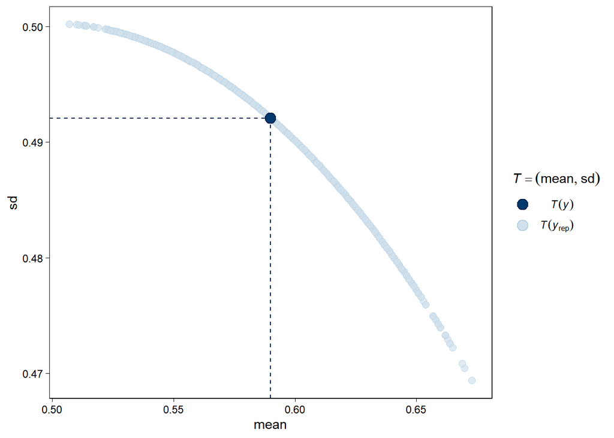

```r
# Not clear how to adjust the titles of these graphs via pp_check when grouped.
# Grouped graphs can be interpreted from T-B and L-R going from
# 1 to 10 in terms of motion sickness
pp_check(model2, type = "stat_2d")
```

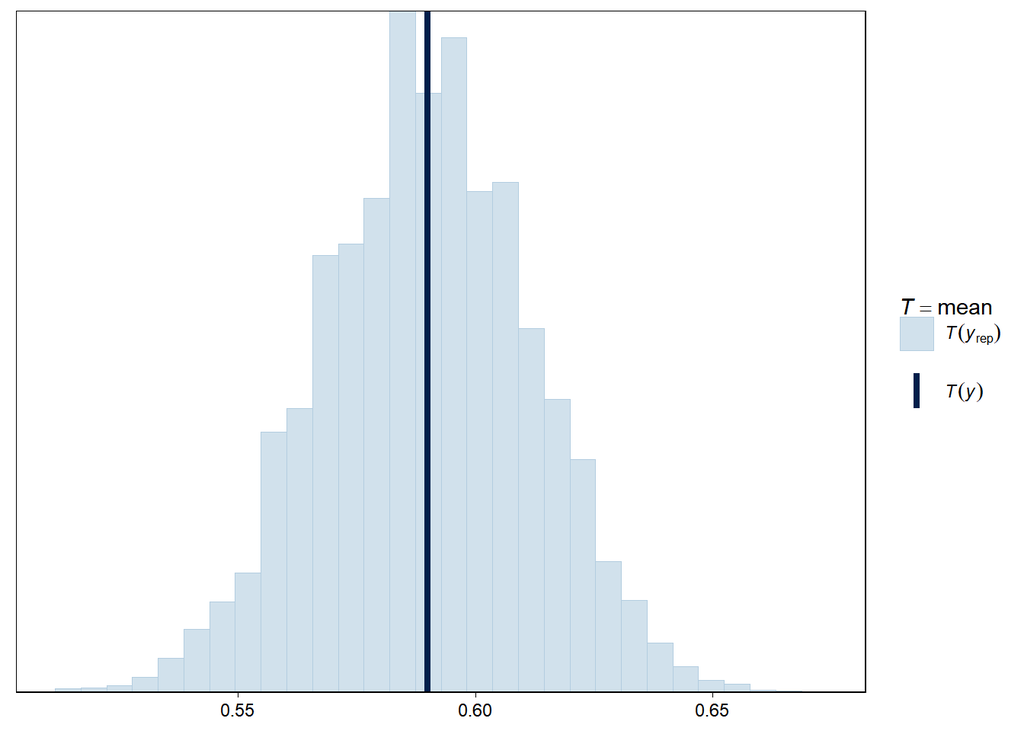

```r
pp_check(model2,type = 'stat')
```

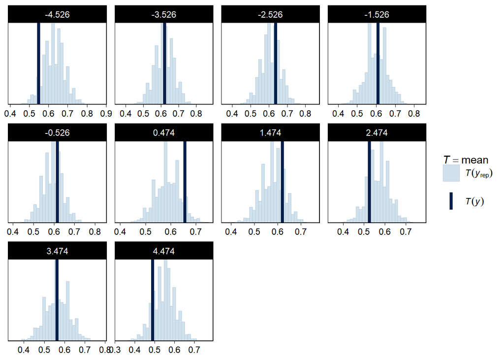

```r
pp_check(model2,type = 'stat_grouped',group = 'MotionSickness')
```

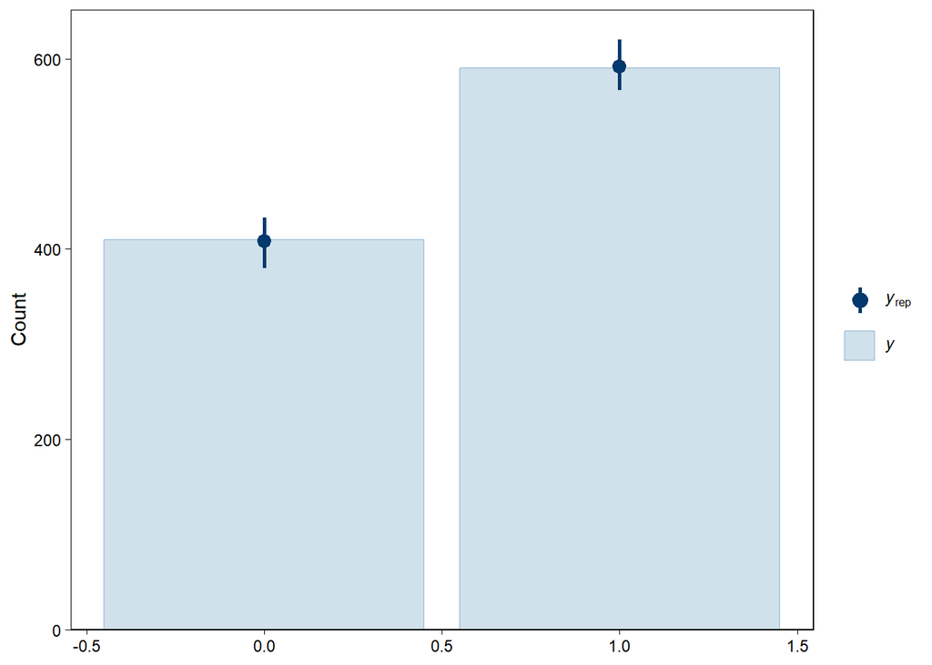

```r
pp_check(model2,type = 'bars')
```

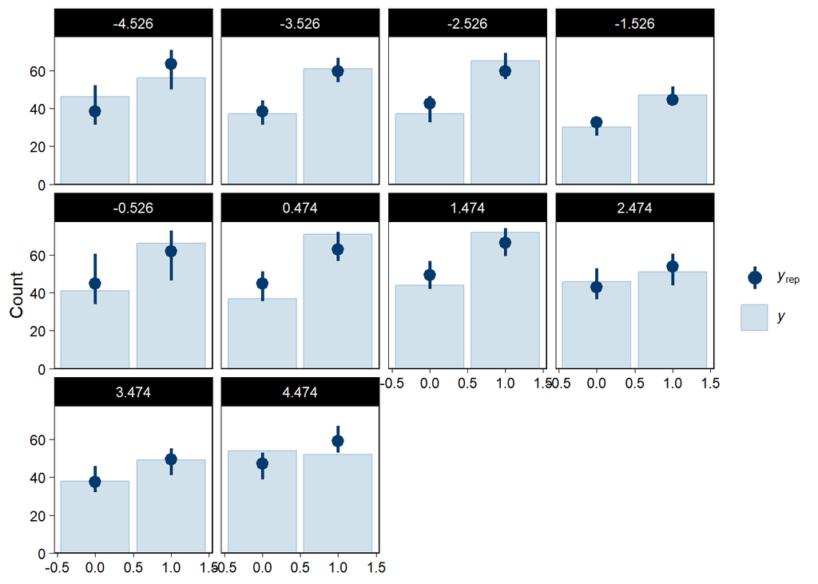

```r
pp_check(model2,type = 'bars_grouped', group = 'MotionSickness')
```

Let us go graph by graph. We find that the first graph shows us a scatterplot of both the mean and the sd. As the proportion of succes in the dataset increase, there appears to be an associated decrease in the standard deviation. The relation between the proportional mean and the standard deviation is given by

$$\sigma_p =
\sqrt{(p(1-p)}$$
The graph shows us that the posterior distribution of proportions and associated standard deviations more or less corresponds to what would be expected given the data.

Similarly, a histogram of the posterior proportional means are normally distributed around the data-provided proportional mean.

Facetting these histograms we find that for the majority of cases, given a Motion Sickness level, the proportional mean of the data and posterior proportions agree. However, sample sizes per group are small due to the granularity of this grouping variable.

**Model 3 - Varying slopes model**

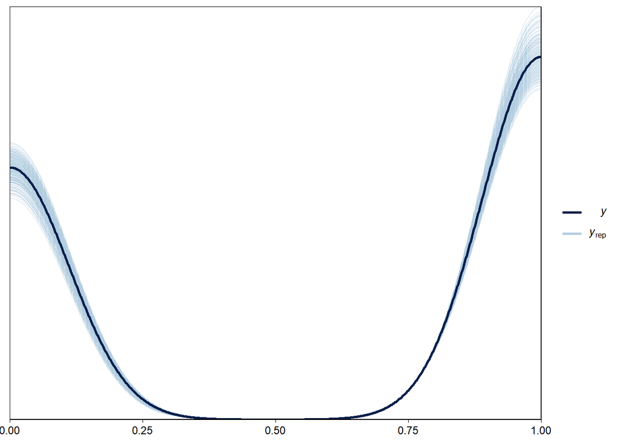

```r
pp_check(model3, ndraws = 200)
```

After conducting a posterior predictive check on the “model3” model, we have the following observations and conclusions:

Adequate Model Fit: The kernel density estimates of the replicated outcomes (y_rep) closely align with the observed outcomes (y), indicating that our model captures the underlying patterns and variability present in the data. This suggests that the relationship between the predictors and the response variable is appropriately represented.

Reasonable Uncertainty Estimation: The spread and shape of the kernel density estimates around the observed outcomes provide a reliable estimation of uncertainty in our model’s predictions. The alignment between the estimates and the observed data suggests that our model’s uncertainty estimation reflects the true variability in the data.

Consistency of Predictions: The close alignment between the observed outcomes and the kernel density estimates of the replicated outcomes demonstrates that our model generates predictions consistent with the observed data. This consistency in predictions further reinforces the reliability of our model for future predictions based on the fitted parameters. In summary, the posterior predictive check confirms that the “model3” model provides an adequate fit, reasonable uncertainty estimation, and consistent predictions with the observed data.

**Model 4 - Varying intercept & slopes model**

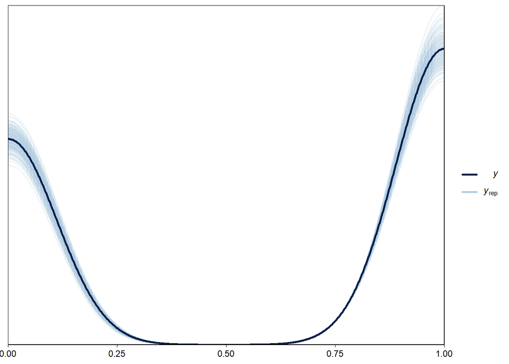

```r
pp_check(model4, ndraws = 200)
```

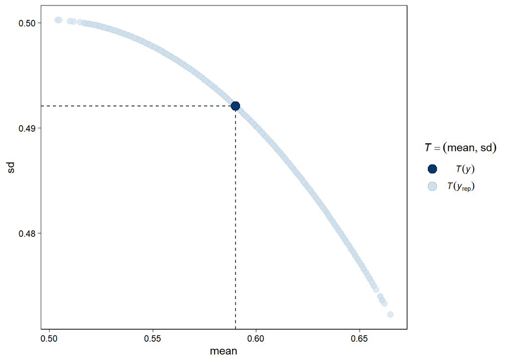

```r
pp_check(model4, type = "stat_2d")
```

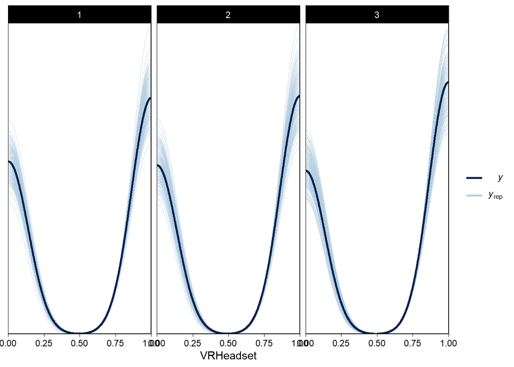

```r
pp_check(model4, ndraws = 200, type = "dens_overlay_grouped",
         group = "VRHeadset") + xlab("VRHeadset")
```

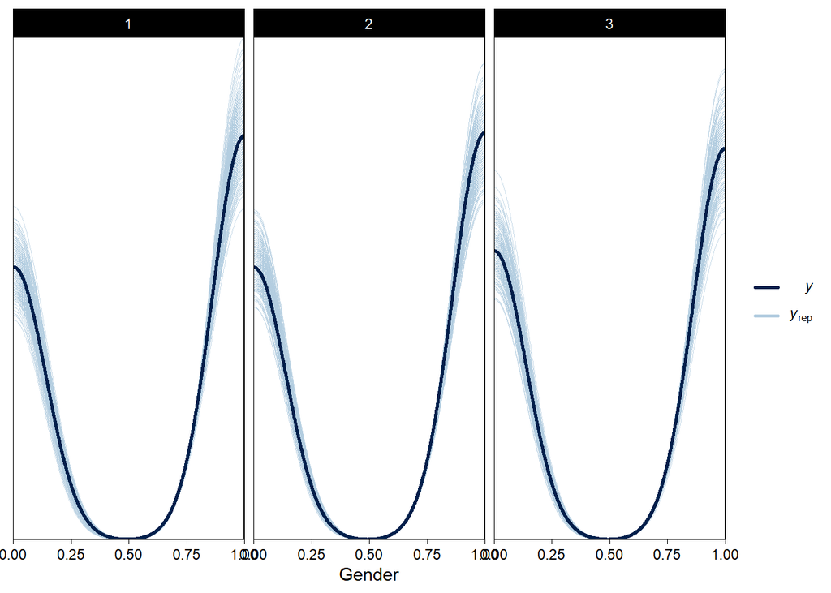

```r
pp_check(model4, ndraws = 200, type = "dens_overlay_grouped",
         group = "Gender") + xlab("Gender")
```

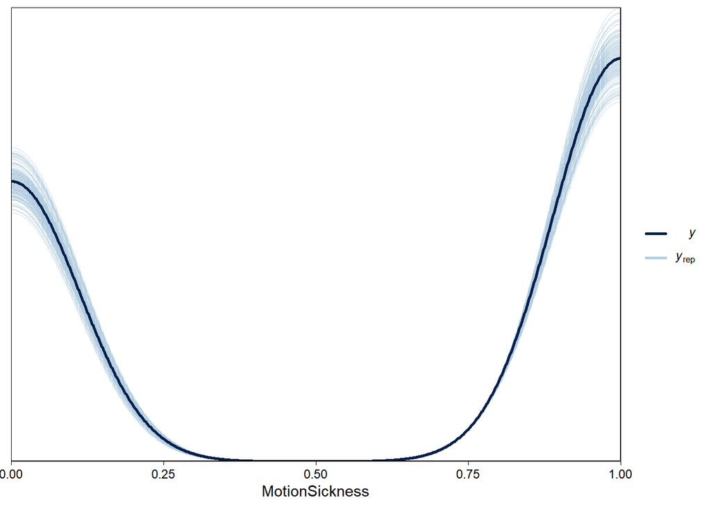

```r
pp_check(model4, ndraws = 200, type = "dens_overlay",
         resp = "MotionSickness") + xlab("MotionSickness")
```

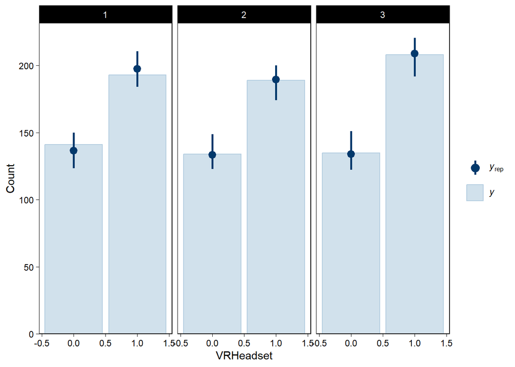

```r
pp_check(model4, type = "bars_grouped", group = "VRHeadset") + xlab("VRHeadset")
```

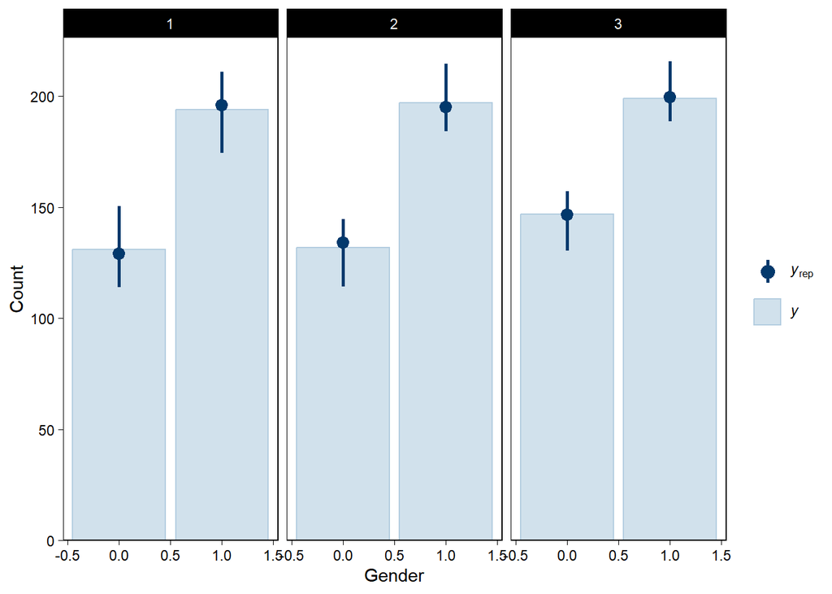

```r
pp_check(model4, type = "bars_grouped", group = "Gender") + xlab("Gender")
```

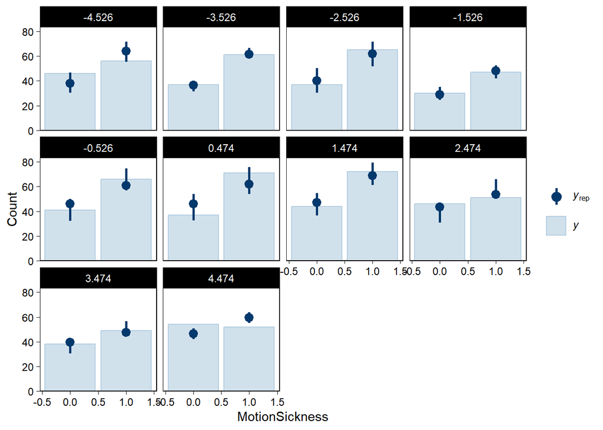

```r
pp_check(model4, type = "bars_grouped", group = "MotionSickness") +
  xlab("MotionSickness")
```

The posterior predictive checks show us that the posterior distribution of a varying slopes and intercepts model seem to be quite accurately distributed around our data. Across groups of VR Headsets and Gender we find that the model fit is very accurate, and similarly we find that the predicted counts by group quite well resemble what the data tells us.

**Model 5 - Correlated varying intercept & varying slopes model**

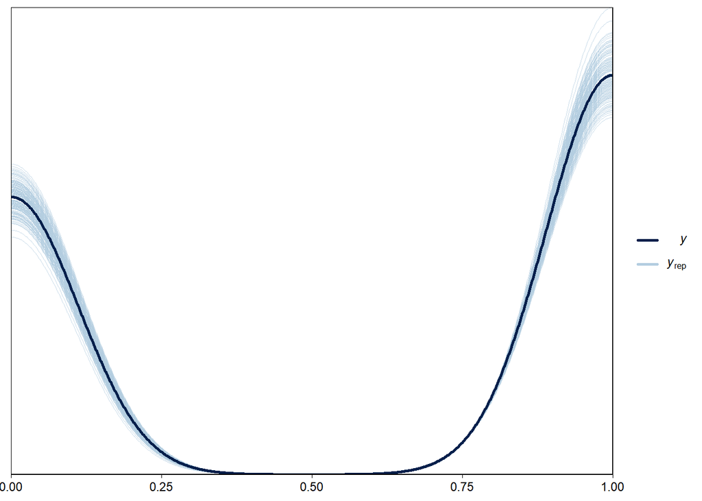

```r
pp_check(model5, ndraws = 200)
```

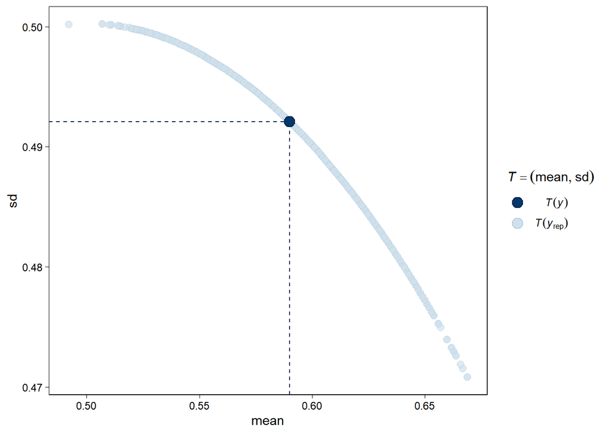

```r
pp_check(model5, type = "stat_2d")
```

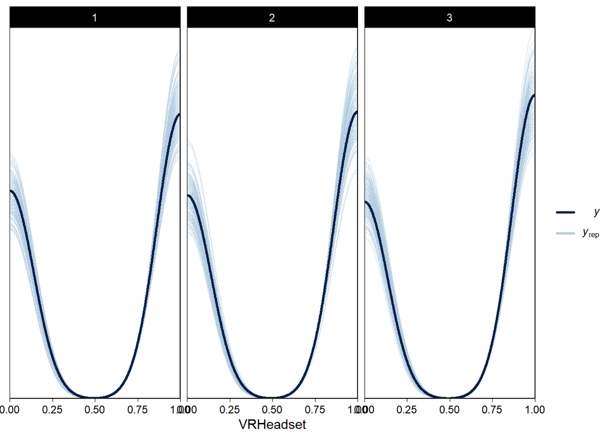

```r
pp_check(model5, ndraws = 200, type = "dens_overlay_grouped",
         group = "VRHeadset") + xlab("VRHeadset")
```

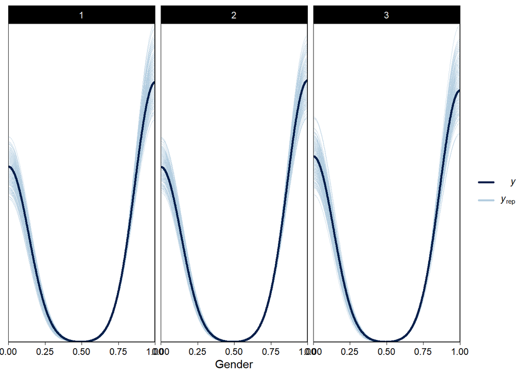

```r
pp_check(model5, ndraws = 200, type = "dens_overlay_grouped",
         group = "Gender") + xlab("Gender")
```

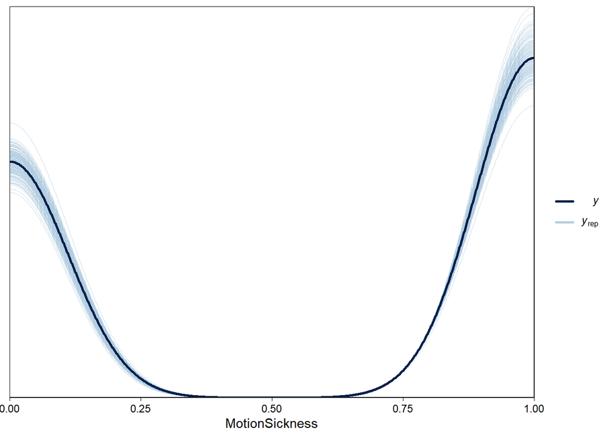

```r
pp_check(model5, ndraws = 200, type = "dens_overlay",
         resp = "MotionSickness") + xlab("MotionSickness")
```

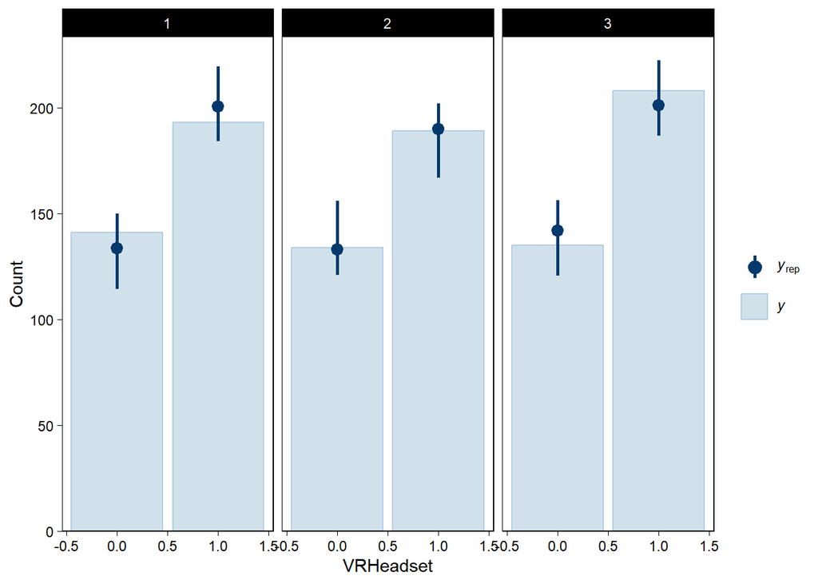

```r
pp_check(model5, type = "bars_grouped", group = "VRHeadset") + xlab("VRHeadset")
```

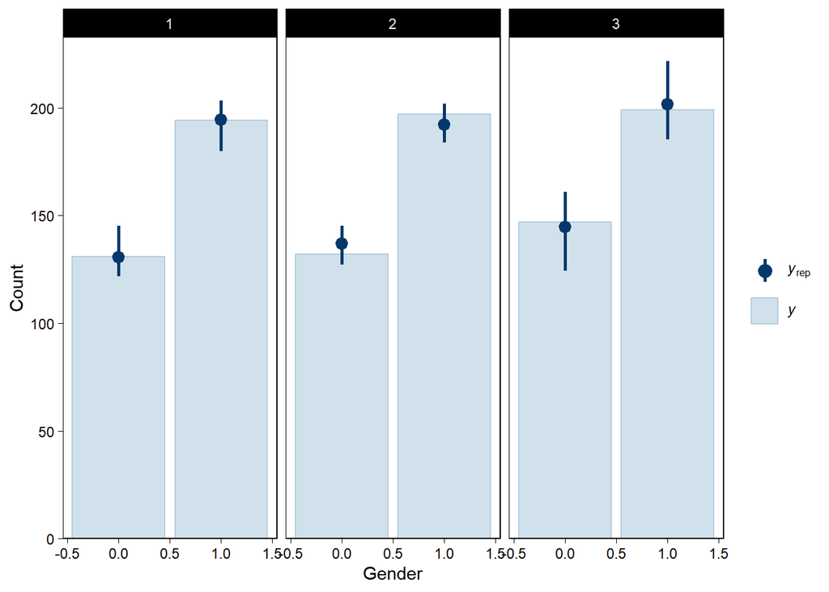

```r
pp_check(model5, type = "bars_grouped", group = "Gender") + xlab("Gender")
```

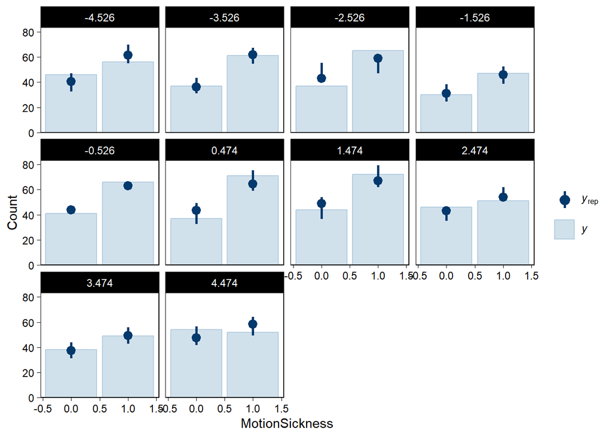

```r
pp_check(model5, type = "bars_grouped", group = "MotionSickness") +
  xlab("MotionSickness")
```

The model seems to fit quite well. Especially for the variables: “Motion Sickness”, “Gender”, and “VR Headset”, the variability could be refined and the fit could be a bit better.

## 5. Model Comparison (1.5pt)

1. Use loo or k-fold cross-validation to compare the models.

```r
cv <- loo(model1,model2,model3,model4,model5,compare = T)
best_model <- attr(cv$diffs,which = 'dimnames')[[1]][1]
cv
```

```
Output of model 'model1':

Computed from 4000 by 1000 log-likelihood matrix

         Estimate   SE
elpd_loo   -678.3  6.0
p_loo         3.1  0.1
looic      1356.5 11.9
------
Monte Carlo SE of elpd_loo is 0.0.

All Pareto k estimates are good (k < 0.5).
See help('pareto-k-diagnostic') for details.

Output of model 'model2':

Computed from 12000 by 1000 log-likelihood matrix

         Estimate   SE
elpd_loo   -677.9  6.2
p_loo         4.1  0.1
looic      1355.8 12.4
------
Monte Carlo SE of elpd_loo is 0.0.

All Pareto k estimates are good (k < 0.5).
See help('pareto-k-diagnostic') for details.

Output of model 'model3':

Computed from 16000 by 1000 log-likelihood matrix

         Estimate   SE
elpd_loo   -680.0  6.6
p_loo        10.1  0.2
looic      1360.0 13.1
------
Monte Carlo SE of elpd_loo is 0.0.

All Pareto k estimates are good (k < 0.5).
```

[output cut: 22 more lines]

```
p_loo         6.9  0.2
looic      1359.0 12.5
------
Monte Carlo SE of elpd_loo is 0.0.

All Pareto k estimates are good (k < 0.5).
See help('pareto-k-diagnostic') for details.

Model comparisons:
       elpd_diff se_diff
model2  0.0       0.0
model1 -0.4       1.7
model5 -1.6       2.5
model3 -2.1       2.0
model4 -3.3       2.2
```

2. Determine the best model based on predictive accuracy and justify your decision.

```r
print(paste0('The best model in absolute terms is: ',best_model))
```

```
[1] "The best model in absolute terms is: model2"
```

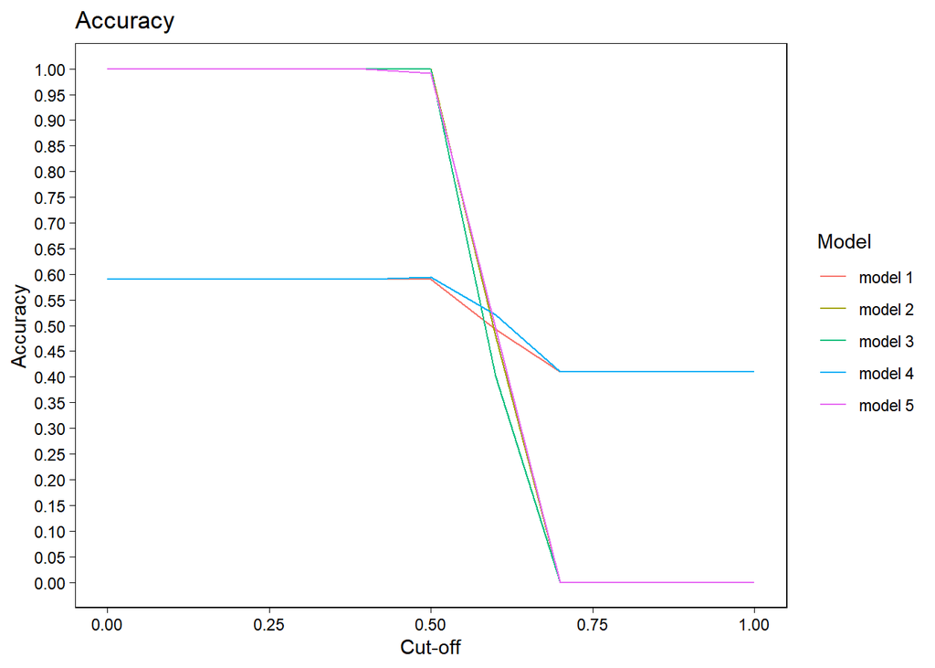

```r
modellist <- list(model1,model2,model3,model4,model5)
classification <- function(model,data,cutoff,response){
  # Sample from the posterior
  predicted <- posterior_predict(object = model,newdata = data)
  # Calculate the proportions of 1s for each data-point
  predicted_prop <- colMeans(x = predicted)
  # Depending on the cut-off classify as 1 or 0
  predicted <- as.factor(ifelse(test = predicted_prop >= cutoff,yes = 1,no = 0))
  # using carets confusionmatrix because the table() doesnt play nice
  clastab <- confusionMatrix(data = predicted,
                             reference = as.factor(response),
                             positive = '1')$table
  # Accuracy rates
  precision = clastab[2,2]/(clastab[2,2] + clastab[1,2])
  recall = clastab[2,2]/(clastab[2,2] + clastab[1,1])
  accuracy = (clastab[1,1] + clastab[2,2])/sum(clastab)
  return(list(classification = clastab,
              accuracy_rates = as.numeric(c(accuracy,recall,precision))))
}

calc_cutoff <- function(modellist,stepsize,data,response){
  # Create a sequence of steps to take
  sequence <- seq(0,1,stepsize)
  # Create a 3 dimensional array to store the data on accuracy rates in for each model
  accarr_array <- array(data = NA,dim = c(length(sequence),3,length(modellist)))
  # Calculate accuracy rates for each model for each possible cutoff specified in sequence
  for(model in 1:length(modellist)){
    for(i in 1:length(sequence)){
      acc_rates <- classification(model = modellist[[model]],data = data,
                                  cutoff = sequence[i],
                                  response = response)$accuracy_rates
      accarr_array[i,,model] <- acc_rates
    }
  }
  # Create modelnames
  modelnames <- c()
  for(i in 1:length(modellist)){
    modelnames[i] <- paste0('model ',i)
  }
  # Return array to matrix form
  arr2mat <- matrix(data = accarr_array,nrow = length(sequence)*length(modellist),
                    ncol = 3)
  # Convert matrix to dataframe for compatability with ggplot2
  # and paste modelnames + cutoff to the side
  arr2mat <- as.data.frame(cbind(arr2mat,rep(x = modelnames,each = length(sequence))))
  arr2mat <- as.data.frame(cbind(arr2mat,rep(x = sequence,times = length(modellist))))
  # Give colnames
  colnames(arr2mat) <- c('Accuracy','Recall','Precision','Model','Cut-off')
  # Melt to long-format from wide
  for(i in 1:dim(arr2mat)[2]){
    if((class(arr2mat[,i]) == 'character') & ( i != 4)){
      arr2mat[,i] <- as.numeric(arr2mat[,i])
    }
  }
  arr2mat
}

# Create data
dat <- calc_cutoff(modellist = modellist,stepsize = 0.1,data = data,
                   response = data$ImmersionLevel)

# Plot accuracy rates separetly and models combined
ggplot(data = dat,aes(x = `Cut-off`,y = Accuracy,group = Model, color = Model)) +
  geom_line() + ggtitle('Accuracy') + scale_y_continuous(breaks = seq(0,1,0.05))
```

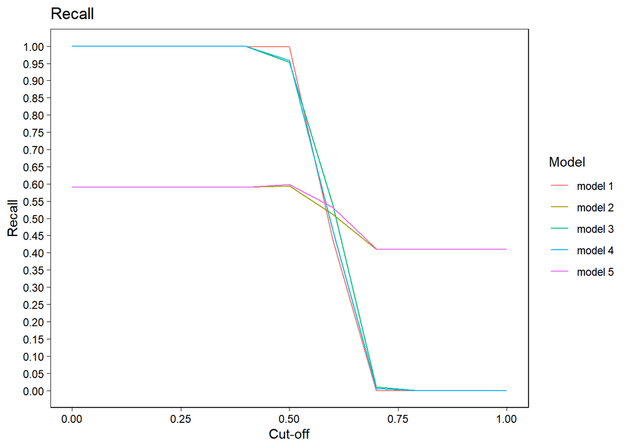

```r
ggplot(data = dat,aes(x = `Cut-off`,y = Recall,group = Model, color = Model)) +
  geom_line() + ggtitle('Recall') + scale_y_continuous(breaks = seq(0,1,0.05))
```

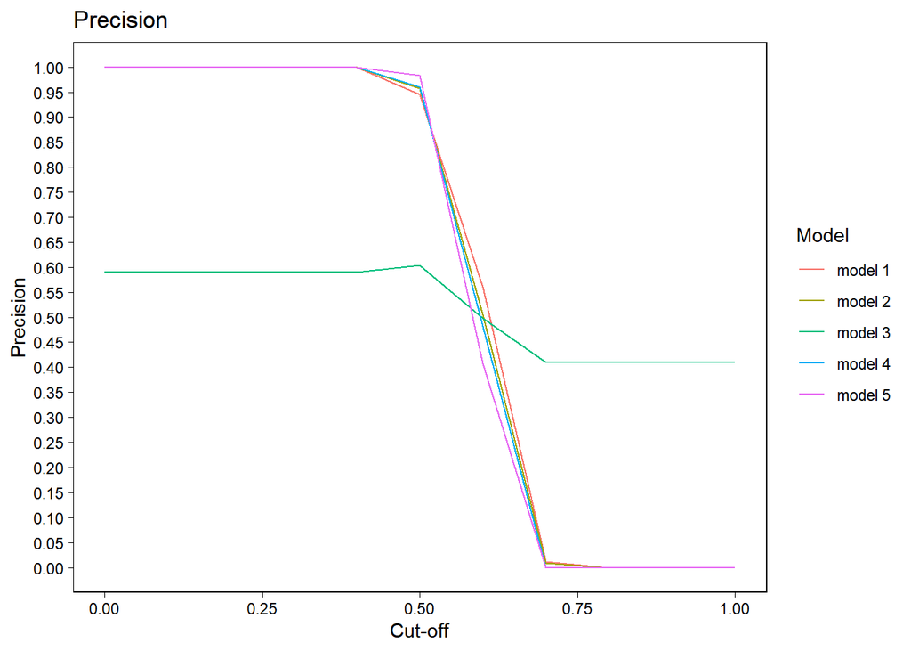

```r
ggplot(data = dat,aes(x = `Cut-off`,y = Precision,group = Model, color = Model)) +
  geom_line() + ggtitle('Precision') + scale_y_continuous(breaks = seq(0,1,0.05))
```

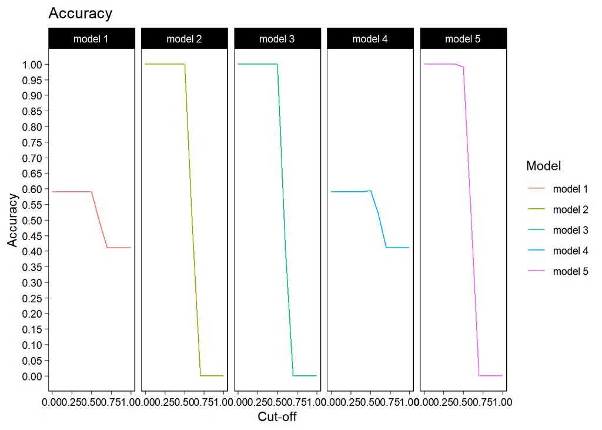

```r
# Plot rates separately and by model
ggplot(data = dat,aes(x = `Cut-off`,y = Accuracy,group = Model, color = Model)) +
  geom_line() + ggtitle('Accuracy') + scale_y_continuous(breaks = seq(0,1,0.05)) +
  facet_grid(~Model)
```

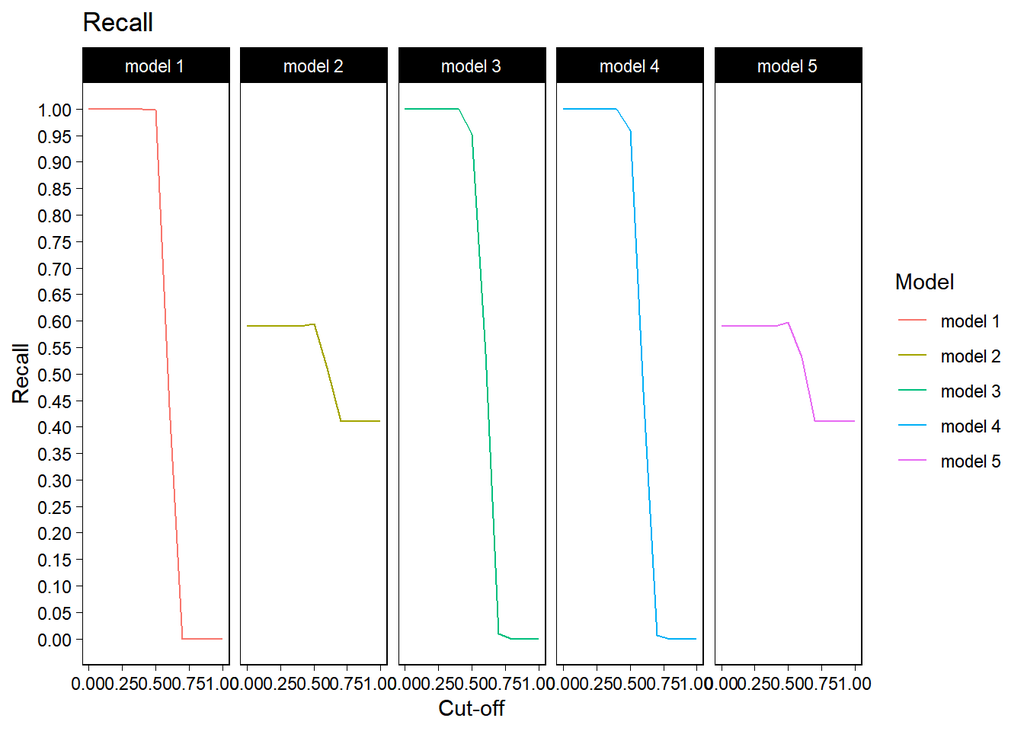

```r
ggplot(data = dat,aes(x = `Cut-off`,y = Recall,group = Model, color = Model)) +
  geom_line() + ggtitle('Recall') + scale_y_continuous(breaks = seq(0,1,0.05))  +
  facet_grid(~Model)
```

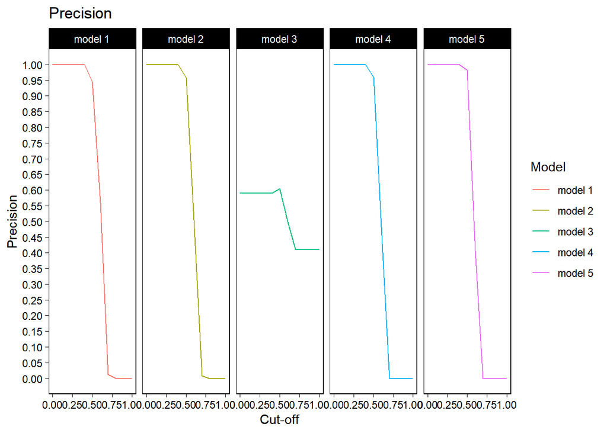

```r
ggplot(data = dat,aes(x = `Cut-off`,y = Precision,group = Model, color = Model)) +
  geom_line() + ggtitle('Precision') + scale_y_continuous(breaks = seq(0,1,0.05)) +
  facet_grid(~Model)
```

The best model so far seems to be model 2. However, the parsimony principle would suggest we favor the first model, a pooled model, over model 2. Though model 2 performed best in absolute terms, there appears no added benefit of using a hierarchical model over a simple pooled model.

Above you find the graphs for three metrics used: Accuracy, Recall and Precision. For varying cut-off scores we calculated the corresponding metrics in order to find an optimal cut-off score for the candidate models. We find that the best cut-off score is in the 40-50% area.

As the graph shows, depending on what metric is most valued, high recall, precision or accuracy one can choose from the available 5 models. All models perform well in two out of three metrics, of which the trade-off in precision, recall or accuracy can be made by the end-user.

## 6. Interpretation of Important Parameters (1.5pt)

Choose one of the best models and interpret its most important parameters in the context of the research question.

- Interpretation of Model 1 and Model 2 - Ebenezer (model 2) & Hamza (model 1)

**Model 1 - Discussion**

```r
# Return parameters Model 1
summary(model1)
```

```
 Family: bernoulli
  Links: mu = logit
Formula: ImmersionLevel ~ Age + Duration
   Data: data (Number of observations: 1000)
  Draws: 4 chains, each with iter = 2000; warmup = 1000; thin = 1;
         total post-warmup draws = 4000

Population-Level Effects:
          Estimate Est.Error l-95% CI u-95% CI Rhat Bulk_ESS Tail_ESS
Intercept     0.37      0.06     0.24     0.49 1.00     4215     2893
Age          -0.02      0.07    -0.15     0.11 1.00     4922     2735
Duration      0.12      0.07    -0.01     0.24 1.00     4366     3170

Draws were sampled using sampling(NUTS). For each parameter, Bulk_ESS
and Tail_ESS are effective sample size measures, and Rhat is the potential
scale reduction factor on split chains (at convergence, Rhat = 1).
```

**Model 2 - Discussion**

```r
# Return parameters Model 2
summary(model2)
```

```
 Family: bernoulli
  Links: mu = logit
Formula: ImmersionLevel ~ MotionSickness + Duration + (1 | VRHeadset)
   Data: data (Number of observations: 1000)
  Draws: 4 chains, each with iter = 6000; warmup = 3000; thin = 1;
         total post-warmup draws = 12000

Group-Level Effects:
~VRHeadset (Number of levels: 3)
              Estimate Est.Error l-95% CI u-95% CI Rhat Bulk_ESS Tail_ESS
sd(Intercept)     0.25      0.41     0.01     1.33 1.00     2100     1725

Population-Level Effects:
               Estimate Est.Error l-95% CI u-95% CI Rhat Bulk_ESS Tail_ESS
Intercept          0.37      0.24    -0.06     0.80 1.00     2539     2059
MotionSickness    -0.03      0.02    -0.08     0.01 1.00     8138     6854
Duration           0.12      0.06    -0.01     0.24 1.00     8673     7338

Draws were sampled using sampling(NUTS). For each parameter, Bulk_ESS
and Tail_ESS are effective sample size measures, and Rhat is the potential
scale reduction factor on split chains (at convergence, Rhat = 1).
```

The second model was a varying intercept model. An exhaustive search was performed using a frequentist approach using the `MuMIn` package, which returned a list of top 10 combinations of best predictive variables. Afterwards, these 10 models were fit using `brms``s `brm` function of which the `loo_compare` function in the `loo` package determined a combination of Duration and Motion Sickness had the best predictive accuracy. Though Gender also being a reasonable grouping variable, VR Headset was ultimately chosen since it is both manipulable and can help in making business decisions in regards to using a particular type of headset for optimal user experience.

The coefficients of this model are based on a mean-centered ordinal variable (Motion Sickness) ranging from 1-10 and on continuous centered data (Duration). We interpret Duration from the perspective of standard deviations deviating from the grand mean of Duration and Motion Sickness as raw points deviating from the mean as well.

```r
summod2 <- summary(model2)
exp(summod2$fixed)
```

```
                Estimate Est.Error  l-95% CI u-95% CI     Rhat Bulk_ESS Tail_ESS
Intercept      1.4423057  1.269665 0.9462251 2.216877 2.722530      Inf      Inf
MotionSickness 0.9657813  1.023084 0.9234502 1.009081 2.719619      Inf      Inf
Duration       1.1227045  1.065103 0.9936045 1.272172 2.720276      Inf      Inf
```

Group-level effects show us the following:

```r
ranef(model2,robust = T)
```

```
$VRHeadset
, , Intercept

       Estimate  Est.Error       Q2.5     Q97.5
1 -1.420497e-02 0.08526252 -0.4902287 0.3848652
2 -7.616303e-05 0.08561648 -0.4428963 0.4392409
3  1.335450e-02 0.08704865 -0.3807575 0.4930111
```

The data above provides us the group-level intercepts of the three headsets included in the model. Here 1 corresponds with the ‘HTC Vive’ , 2 with the ‘Playstation VR’ and 3 with the ‘Oculus Rift’. We make use of robust coefficients by using the median as the central tendency parameter and the measure of variability being the MAD.

Interpreting these (logged) group-level effects show us estimates that are offsets from the population-level intercept shown earlier, representing the base probability of an individual feeling immersed. As such, we can conclude that the ‘Oculus Rift’ VR Headset is the largest. However, the standard error of not just this VR Headset but all of the VR Headsets are large enough that they do not significantly deviate from zero, as we can see zero being well within the 2.5% and 97.5% interval. As such we can neglect including the group-level effects when making predictions about the probability of an individual feeling Immersed or not.

We can conclude that a pooled model is probably the better and more parsimonious model to represent this data set given our results in section 5 where model 1 in absolute terms did not significantly differ in predictive accuracy from model 2, or any other of the more complex models. However, as mentioned previously in section 5, depending on the desired model metrics and associated optimal cut-off scores the end-user may opt for a different model than model 2 or model 1.

**Considerations between using a pooled model and a (Generalized) Multilevel Model**

*Reasons for choosing a (Generalized) Multilevel Model*

There are a few considerations to consider when deciding between using a Multilevel Model or not using a Multilevel model. Some key factors for using a Multilevel model are:

Multilevel models are suitable when the data has a hierarchical or nested structure. For example, when it’s collected from individuals within groups or when it consists of repeated measurements over time. They can capture the variability at multiple levels and account for dependencies among observations.*

Multilevel models allow for the incorporation of prior information or beliefs about the parameters into the analysis. This can be helpful when you have prior knowledge about the data generating process or when you want to update your beliefs based on previous studies.*

Multilevel models can handle situations where you have limited data at the individual level but have enough groups. By borrowing strength from other groups, the multilevel structure can provide more stable and reliable estimates than standard models that treat all observations as independent.

*Reasons why not to use (Generalized) Multilevel Model*

The data does not have a hierarchical structure, and the observations can be considered as independent from one another.

You want the model to be simpler to interpret. These may be more suitable when you have a relatively small dataset, limited computational resources, or when the research question can be adequately addressed without considering group-level effects.

You have reasons to believe that the effects of predictors are constant across all groups, there may be no need for a multilevel model. Non-multilevel models assume that the relationships between predictors and the outcome variable are the same for all observations.

Non multilevel models can be computationally more efficient, especially when dealing with large datasets, as they do not involve estimating multiple levels of parameters.

**On Priors**

Priors are assumptions or beliefs about the distribution of the parameters in a statistical model. In this case, the priors are specified for the standard deviation (sd) of the data in a logistic regression model.

The prior for the standard deviation is set as an exponential distribution with a rate parameter calculated as the reciprocal of the standard deviation of the ImmersionLevel variable in the dataset. This choice of prior is considered uninformative, meaning it does not strongly influence the model and allows the data to drive the inference.

Using an uninformative prior helps avoid biasing the results based on strong prior assumptions. By using a relatively flat prior distribution, the model becomes more reliant on the data itself to estimate the parameters.

These priors are chosen to be relatively uninformative, allowing the model to rely more on the observed data to estimate the parameters of interest.

## 7. Utility theory. Bonus (Optional for 2 extra pts)

Derive a utility function and demonstrate how it can be used to make an optimal decision based on the fitted models and their parameters.

```r
m_U <- brm(ImmersionLevel ~ Age + Gender + VRHeadset + Duration + MotionSickness,
                      data = data, family = bernoulli(), file = 'm_U', save_model = 'm_U')

find_optimal_motion_sickness <- function(age, gender, vr_headset, duration) {
  motion_sickness_range <- seq(0, 10, 1)
  predicted_immersions <- sapply(motion_sickness_range, function(ms) {
    new_data <- data.frame(Age = age, Gender = as.numeric(gender),
                           VRHeadset = vr_headset,
                           Duration = duration, MotionSickness = ms)
    predict(m_U, newdata = new_data, type = "response")
  })
  optimal_ms <- motion_sickness_range[which.max(predicted_immersions)]
  return(optimal_ms)
}

age <- 0.5
gender <- 1
vr_headset <- 2
duration <- 1
optimal_motion_sickness <- find_optimal_motion_sickness(age, gender, vr_headset, duration)
print(optimal_motion_sickness)
```

```
[1] 3
```

A utility function is generated to find the optimal level of motion sickness which maximizes the predicted immersion level for a given set of variables. Based on the input values of age = 0.5, gender = 1, vr_headset = 2, and duration = 1, the optimal level of motion sickness is 3 in this case.

# Contributions of each member

- Hamza Sajjad: Complete Pooling Model (Section 3-4) - Section 6 (Interpretation model 1) - Section 7
- Ebenezer Tafese: Varying Intercepts Model (Section 3-4), Section 5, Overall code contribution management - Section 6 (Interpretation model 2))
- Kafia Elmi: Varying Slopes Model (Section 3-4)- Section 6 (Priors)
- Natalia Latinović: Varying Intercept and Varying Slopes Model (Section 3-4)- Section 6 (Considerations)
- Bas Verkennis: Search dataset, write question 1, Correlated Varying Intercept and Varying Slopes Model (Section 3-4)

# References

Akash, J. (n.d.). *Virtual Reality Experiences: Analyzing VR user experiences improves design, comfort, and customization.* [Kaggle]. https://www.kaggle.com/datasets/aakashjoshi123/virtual-reality-experiences